```r
cd4 = read.table("C:/Users/LEGION/OneDrive - Duke University/610/cd4.dat", header = TRUE)
cd4$pid = as.factor(cd4$pid)
```

### 3(a)

```r
library(lme4)
library(dplyr)
library(tibble)
lmem <- lmer(cd4 ~ as.factor(trt) + time + as.factor(trt)*time + (time|pid), data=cd4, REML=FALSE)
summary(lmem)
```

```
## Linear mixed model fit by maximum likelihood  ['lmerMod']
## Formula: cd4 ~ as.factor(trt) + time + as.factor(trt) * time + (time |
##     pid)
##    Data: cd4
##
##      AIC      BIC   logLik deviance df.resid
##   3119.4   3159.2  -1551.7   3103.4     1064
##
## Scaled residuals:
##     Min      1Q  Median      3Q     Max
## -5.0924 -0.3978  0.0061  0.4101  5.0207
##
## Random effects:
##  Groups   Name        Variance Std.Dev. Corr
##  pid      (Intercept) 1.9083   1.3814
##           time        0.3309   0.5753   -0.06
##  Residual             0.5147   0.7174
## Number of obs: 1072, groups:  pid, 250
##
## Fixed effects:
##                      Estimate Std. Error t value
## (Intercept)           4.82628    0.13671  35.303
## as.factor(trt)1      -0.12792    0.18934  -0.676
## time                 -0.30623    0.09871  -3.102
## as.factor(trt)1:time -0.08943    0.13496  -0.663
##
## Correlation of Fixed Effects:
##             (Intr) as.()1 time
## as.fctr(t)1 -0.722
## time        -0.238  0.172
## as.fctr()1:  0.174 -0.243 -0.731
```

```r
confint(lmem, level = 0.95)
```

```
##                           2.5 %     97.5 %
## .sig01                1.2474912  1.5336904
## .sig02               -0.3015835  0.2245120
## .sig03                0.4227833  0.7290044
## .sigma                0.6800689  0.7581767
## (Intercept)           4.5570316  5.0950726
## as.factor(trt)1      -0.5002298  0.2448533
## time                 -0.5022743 -0.1086288
## as.factor(trt)1:time -0.3565953  0.1774465
```

#### Confident intervals:

- Treatment: [−0.5002298,0.2448533]
- Time: [−0.5022743,−0.1086288]
- Interaction of treatment and time: [−0.3565953,0.1774465]

To find evidence for evidence for a treatment effect, we shall look at each effect separately.

#### Comparing the two methods:

In the last homework, we used linear model and ANOVA test to determine if there is treatment effect. Specifically, the linear model provided significant evidence for a treatment effect based on the ANOVA test. However, this method does not account for individual subject variability (pid). In the current mixed-effects model, we see that while the model accounts for heterogeneity across subjects, the fixed effects for treatment and treatment-time interaction were not statistically significant. This suggests that after properly accounting for subject-level variability, the treatment effect is not as strong or as significant as it appeared in the simpler linear models.

Also, in the last homework, it was shown that treatment and pid were confounded, meaning that each subject was only exposed to one treatment level. This meant that separating the effects of pid and trt was impossible in that fixed-effects-only model. The mixed-effects model, we now handle this by allowing random effects for pid, which separates the treatment effects from the individual variability across subjects.

### 3(b)

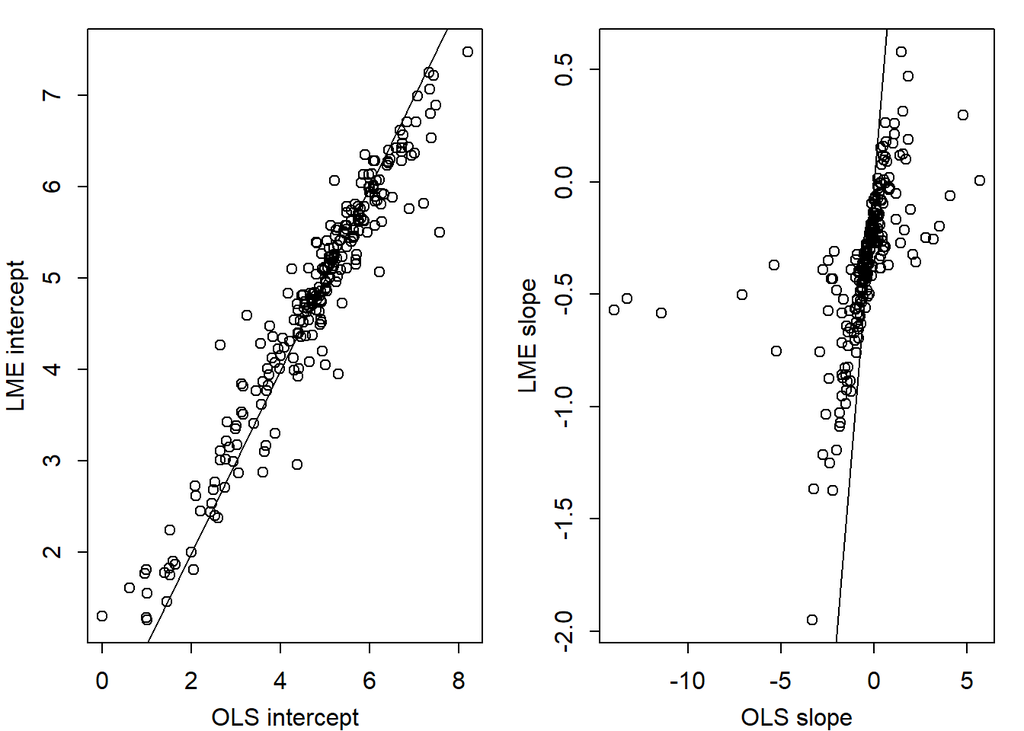

```r
mpar<-function(...){par(mar=c(3,3,1,1),mgp=c(2,.75,0),tck=-.025,...)}
par(mfrow=c(1,2))
mpar()
BETA.OLS <- NULL
DF <- SSE <- 0
for (j in unique(cd4$pid)) {
  yj <- cd4$cd4[cd4$pid == j]
  xj <- cd4$time[cd4$pid == j]
  fitj <- lm(yj ~ xj)
  BETA.OLS <- rbind(BETA.OLS, fitj$coefficients)
  if (length(yj) >= 2) {
    SSE <- SSE + sum(fitj$residuals^2)
    DF <- DF + length(yj) - 2
  }
}
fixed_effects <- fixef(lmem)
random_effects <- ranef(lmem)$pid
subject_data <- cd4 %>%
  group_by(pid) %>%
  summarise(trt = unique(trt))
random_effects <- as.data.frame(random_effects) %>%
  rownames_to_column(var = "pid") %>%
  left_join(subject_data, by = "pid")
random_effects <- random_effects %>%
  mutate(
    # For intercept, if trt = 0 use beta_0 + (Intercept), else beta_0 + beta_1 + (Intercept)
    final_intercept = ifelse(trt == 0, fixed_effects[1] + `(Intercept)`, fixed_effects[1] + fixed_effects[2] + `(Intercept)`),
    # For slope, if trt = 0 use beta_2 + time, else beta_2 + beta_3 + time
    final_slope = ifelse(trt == 0, fixed_effects[3] + time, fixed_effects[3] + fixed_effects[4] + time)
  )
s2.ols <- SSE / DF
plot(BETA.OLS[,1],random_effects[, 'final_intercept'],xlab="OLS intercept",ylab="LME intercept",)
abline(0, 1)
plot(BETA.OLS[,2],random_effects[, 'final_slope'],xlab="OLS slope",ylab="LME slope",)
abline(0, 1)
```

The LME model’s intercept estimates are largely consistent with the OLS intercepts, with minimal shrinkage. This indicates that subject-specific intercepts don’t differ much from the population average in the LME model.

The LME model significantly shrinks the slope estimates toward zero, which suggests that the model assumes less subject-specific variability in the slopes compared to OLS. This is particularly true for subjects with more extreme OLS slopes, where the LME estimates bring them closer to the population average.

We will now plot the estimate differences for both intercept and slope vs. sample sizes.

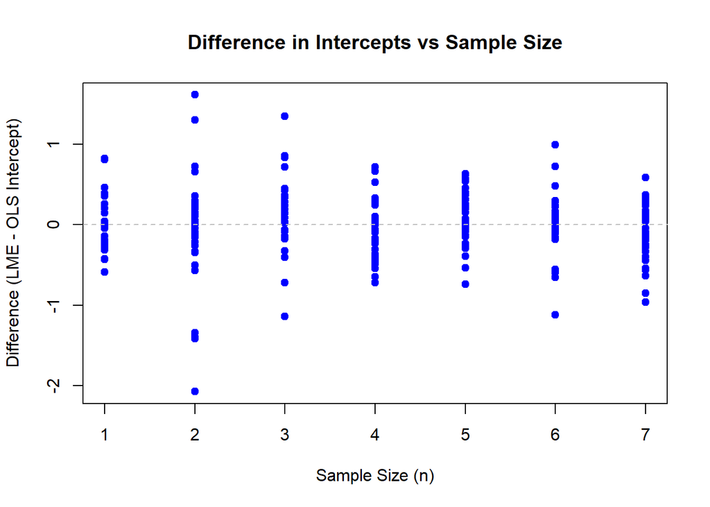

```r
sample_size <- cd4 %>%
  group_by(pid) %>%
  summarise(sample_size = n())
final_data <- data.frame(
  pid = random_effects$pid,
  OLS_intercept = BETA.OLS[,1],
  LME_intercept = random_effects$final_intercept,
  LME_slope = random_effects$final_slope,
  OLS_slope = BETA.OLS[,2]
)
final_data <- final_data %>%
  left_join(sample_size, by = "pid")
final_data <- final_data %>%
  mutate(difference_intercept = LME_intercept - OLS_intercept,
         difference_slope = LME_slope - OLS_slope)
plot(final_data$sample_size, final_data$difference_intercept,
     xlab = "Sample Size (n)",
     ylab = "Difference (LME - OLS Intercept)",
     main = "Difference in Intercepts vs Sample Size",
     pch = 19, col = "blue")
abline(h = 0, col = "gray", lty = 2)
```

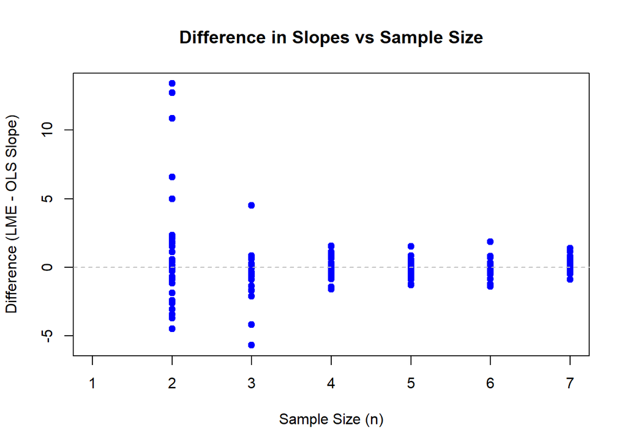

```r
plot(final_data$sample_size, final_data$difference_slope,
     xlab = "Sample Size (n)",
     ylab = "Difference (LME - OLS Slope)",
     main = "Difference in Slopes vs Sample Size",
     pch = 19, col = "blue")
abline(h = 0, col = "gray", lty = 2)
```

### 3(c)

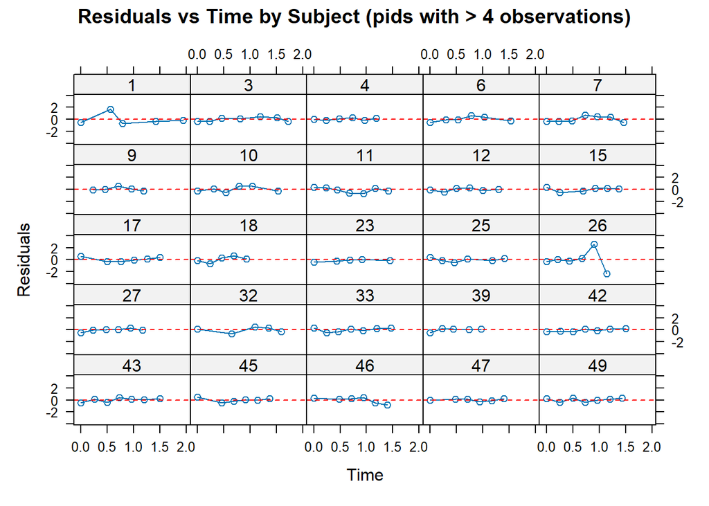

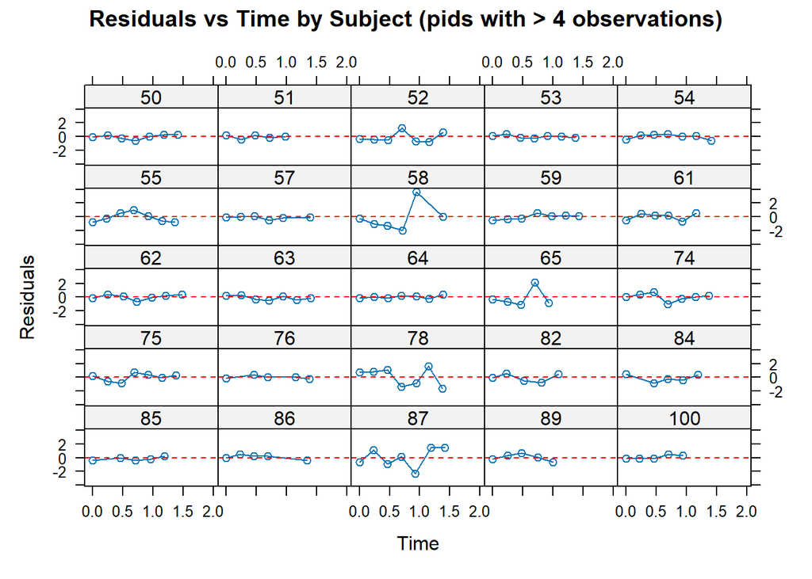

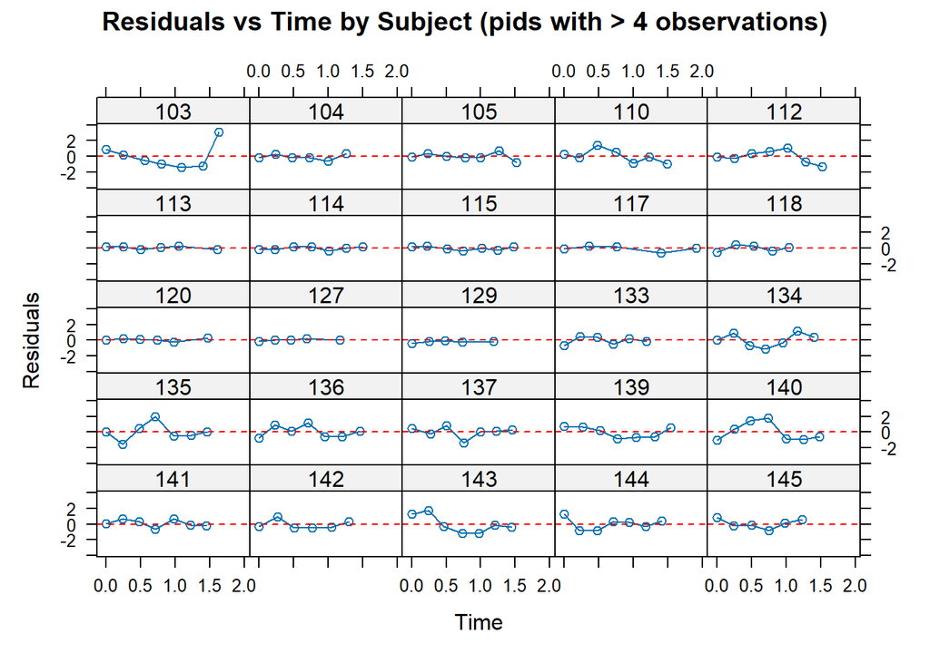

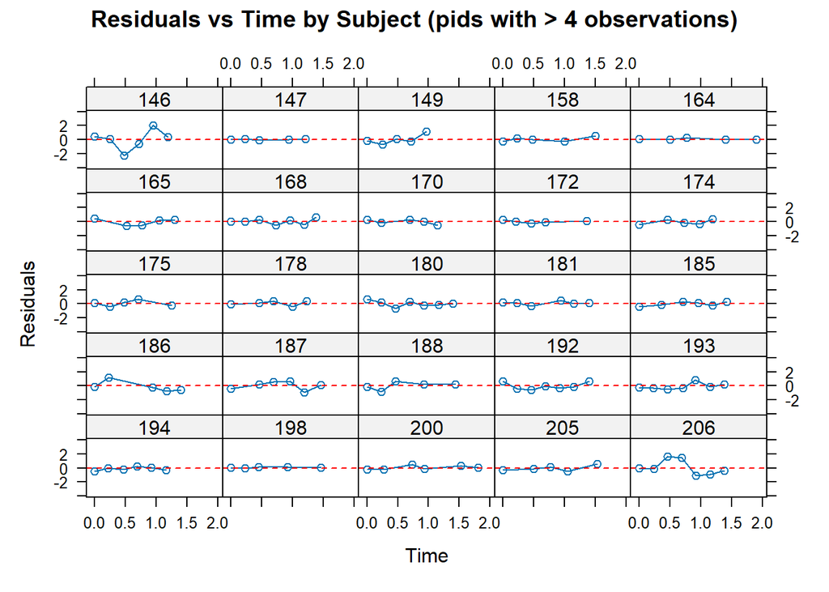

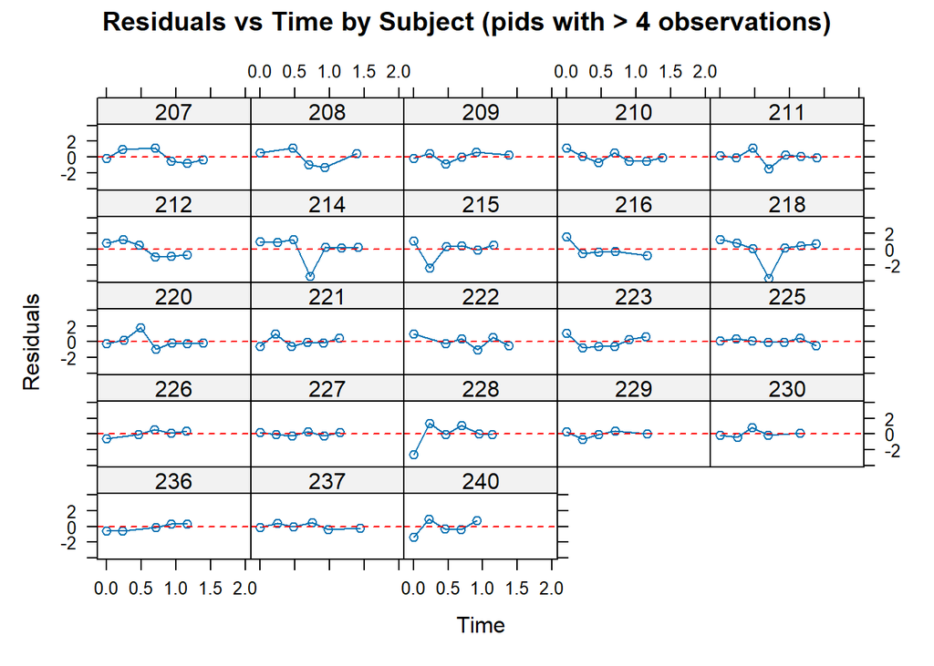

```r
library(lattice)
library(dplyr)

fitted_values <- fitted(lmem)
cd4$residuals <- cd4$cd4 - fitted_values

plotdf <- data.frame(
  pid = cd4$pid,
  time = cd4$time,
  residuals = cd4$residuals,
  fitted_values = fitted_values
)

# Filter for pids with more than 4 observations
filtered_data <- plotdf %>%
  group_by(pid) %>%
  filter(n() > 4) %>%
  ungroup()

xyplot(residuals ~ time | factor(pid),
       data = filtered_data,
       type = "b",
       layout = c(5, 5),
       as.table = TRUE,
       xlab = "Time",
       ylab = "Residuals",
       main = "Residuals vs Time by Subject (pids with > 4 observations)",
       panel = function(x, y, ...) {
         panel.xyplot(x, y, ...)
         panel.abline(h = 0, col = "red", lty = 2)  # Add a red dashed horizontal line at y = 0
       }
)
```

From the plots above, we finds out that in most cases, the residuals appear to fluctuate around zero without a noticeable trend. This is a good indication that the model is not systematically biased in overpredicting or underpredicting values for these subjects. For most subjects, there do not appear to be strong patterns over time, such as increasing or decreasing residuals, which would violate the independence assumption. The residuals appear randomly distributed around the red dashed line, which supports the conditional independence assumption. In some subjects, the residuals show small fluctuations, but this may be due to noise rather than a systematic violation of independence.

In conclusion, the assumption of conditional independence of $\epsilon_{ij}$ within each subject seems reasonable based on these residual plots. The residuals do not show significant autocorrelation or patterns over time that would suggest otherwise.